# Employee Attrition-Copy1

```python
import pandas as pd
import numpy as np
import matplotlib.pyplot as plt
import seaborn as sns
```

```python
data = pd.read_csv("E://EmployeeAttrition.csv")
```

```python
data
```

|  | Age | Attrition | BusinessTravel | DailyRate | Department | DistanceFromHome | Education | EducationField | EmployeeCount | EmployeeNumber | ... | RelationshipSatisfaction | StandardHours | StockOptionLevel | TotalWorkingYears | TrainingTimesLastYear | WorkLifeBalance | YearsAtCompany | YearsInCurrentRole | YearsSinceLastPromotion | YearsWithCurrManager |
| --- | --- | --- | --- | --- | --- | --- | --- | --- | --- | --- | --- | --- | --- | --- | --- | --- | --- | --- | --- | --- | --- |
| 0 | 41 | Yes | Travel_Rarely | 1102 | Sales | 1 | 2 | Life Sciences | 1 | 1 | ... | 1 | 80 | 0 | 8 | 0 | 1 | 6 | 4 | 0 | 5 |
| 1 | 49 | No | Travel_Frequently | 279 | Research & Development | 8 | 1 | Life Sciences | 1 | 2 | ... | 4 | 80 | 1 | 10 | 3 | 3 | 10 | 7 | 1 | 7 |
| 2 | 37 | Yes | Travel_Rarely | 1373 | Research & Development | 2 | 2 | Other | 1 | 4 | ... | 2 | 80 | 0 | 7 | 3 | 3 | 0 | 0 | 0 | 0 |
| 3 | 33 | No | Travel_Frequently | 1392 | Research & Development | 3 | 4 | Life Sciences | 1 | 5 | ... | 3 | 80 | 0 | 8 | 3 | 3 | 8 | 7 | 3 | 0 |
| 4 | 27 | No | Travel_Rarely | 591 | Research & Development | 2 | 1 | Medical | 1 | 7 | ... | 4 | 80 | 1 | 6 | 3 | 3 | 2 | 2 | 2 | 2 |
| ... | ... | ... | ... | ... | ... | ... | ... | ... | ... | ... | ... | ... | ... | ... | ... | ... | ... | ... | ... | ... | ... |
| 1465 | 36 | No | Travel_Frequently | 884 | Research & Development | 23 | 2 | Medical | 1 | 2061 | ... | 3 | 80 | 1 | 17 | 3 | 3 | 5 | 2 | 0 | 3 |
| 1466 | 39 | No | Travel_Rarely | 613 | Research & Development | 6 | 1 | Medical | 1 | 2062 | ... | 1 | 80 | 1 | 9 | 5 | 3 | 7 | 7 | 1 | 7 |
| 1467 | 27 | No | Travel_Rarely | 155 | Research & Development | 4 | 3 | Life Sciences | 1 | 2064 | ... | 2 | 80 | 1 | 6 | 0 | 3 | 6 | 2 | 0 | 3 |
| 1468 | 49 | No | Travel_Frequently | 1023 | Sales | 2 | 3 | Medical | 1 | 2065 | ... | 4 | 80 | 0 | 17 | 3 | 2 | 9 | 6 | 0 | 8 |
| 1469 | 34 | No | Travel_Rarely | 628 | Research & Development | 8 | 3 | Medical | 1 | 2068 | ... | 1 | 80 | 0 | 6 | 3 | 4 | 4 | 3 | 1 | 2 |

1470 rows × 35 columns

Basic data Exploration:

```python
data.head()
```

|  | Age | Attrition | BusinessTravel | DailyRate | Department | DistanceFromHome | Education | EducationField | EmployeeCount | EmployeeNumber | ... | RelationshipSatisfaction | StandardHours | StockOptionLevel | TotalWorkingYears | TrainingTimesLastYear | WorkLifeBalance | YearsAtCompany | YearsInCurrentRole | YearsSinceLastPromotion | YearsWithCurrManager |
| --- | --- | --- | --- | --- | --- | --- | --- | --- | --- | --- | --- | --- | --- | --- | --- | --- | --- | --- | --- | --- | --- |
| 0 | 41 | Yes | Travel_Rarely | 1102 | Sales | 1 | 2 | Life Sciences | 1 | 1 | ... | 1 | 80 | 0 | 8 | 0 | 1 | 6 | 4 | 0 | 5 |
| 1 | 49 | No | Travel_Frequently | 279 | Research & Development | 8 | 1 | Life Sciences | 1 | 2 | ... | 4 | 80 | 1 | 10 | 3 | 3 | 10 | 7 | 1 | 7 |
| 2 | 37 | Yes | Travel_Rarely | 1373 | Research & Development | 2 | 2 | Other | 1 | 4 | ... | 2 | 80 | 0 | 7 | 3 | 3 | 0 | 0 | 0 | 0 |
| 3 | 33 | No | Travel_Frequently | 1392 | Research & Development | 3 | 4 | Life Sciences | 1 | 5 | ... | 3 | 80 | 0 | 8 | 3 | 3 | 8 | 7 | 3 | 0 |
| 4 | 27 | No | Travel_Rarely | 591 | Research & Development | 2 | 1 | Medical | 1 | 7 | ... | 4 | 80 | 1 | 6 | 3 | 3 | 2 | 2 | 2 | 2 |

5 rows × 35 columns

```python
pd.set_option('display.max_columns',None)
```

```python
data.head()
```

|  | Age | Attrition | BusinessTravel | DailyRate | Department | DistanceFromHome | Education | EducationField | EmployeeCount | EmployeeNumber | EnvironmentSatisfaction | Gender | HourlyRate | JobInvolvement | JobLevel | JobRole | JobSatisfaction | MaritalStatus | MonthlyIncome | MonthlyRate | NumCompaniesWorked | Over18 | OverTime | PercentSalaryHike | PerformanceRating | RelationshipSatisfaction | StandardHours | StockOptionLevel | TotalWorkingYears | … |
| --- | --- | --- | --- | --- | --- | --- | --- | --- | --- | --- | --- | --- | --- | --- | --- | --- | --- | --- | --- | --- | --- | --- | --- | --- | --- | --- | --- | --- | --- | --- |
| 0 | 41 | Yes | Travel_Rarely | 1102 | Sales | 1 | 2 | Life Sciences | 1 | 1 | 2 | Female | 94 | 3 | 2 | Sales Executive | 4 | Single | 5993 | 19479 | 8 | Y | Yes | 11 | 3 | 1 | 80 | 0 | 8 | … |
| 1 | 49 | No | Travel_Frequently | 279 | Research & Development | 8 | 1 | Life Sciences | 1 | 2 | 3 | Male | 61 | 2 | 2 | Research Scientist | 2 | Married | 5130 | 24907 | 1 | Y | No | 23 | 4 | 4 | 80 | 1 | 10 | … |
| 2 | 37 | Yes | Travel_Rarely | 1373 | Research & Development | 2 | 2 | Other | 1 | 4 | 4 | Male | 92 | 2 | 1 | Laboratory Technician | 3 | Single | 2090 | 2396 | 6 | Y | Yes | 15 | 3 | 2 | 80 | 0 | 7 | … |
| 3 | 33 | No | Travel_Frequently | 1392 | Research & Development | 3 | 4 | Life Sciences | 1 | 5 | 4 | Female | 56 | 3 | 1 | Research Scientist | 3 | Married | 2909 | 23159 | 1 | Y | Yes | 11 | 3 | 3 | 80 | 0 | 8 | … |
| 4 | 27 | No | Travel_Rarely | 591 | Research & Development | 2 | 1 | Medical | 1 | 7 | 1 | Male | 40 | 3 | 1 | Laboratory Technician | 2 | Married | 3468 | 16632 | 9 | Y | No | 12 | 3 | 4 | 80 | 1 | 6 | … |

```python
data.info()
```

```
<class 'pandas.core.frame.DataFrame'>
RangeIndex: 1470 entries, 0 to 1469
Data columns (total 35 columns):
 #   Column                    Non-Null Count  Dtype
---  ------                    --------------  -----
 0   Age                       1470 non-null   int64
 1   Attrition                 1470 non-null   object
 2   BusinessTravel            1470 non-null   object
 3   DailyRate                 1470 non-null   int64
 4   Department                1470 non-null   object
 5   DistanceFromHome          1470 non-null   int64
 6   Education                 1470 non-null   int64
 7   EducationField            1470 non-null   object
 8   EmployeeCount             1470 non-null   int64
 9   EmployeeNumber            1470 non-null   int64
```

[output cut: 27 more lines]

```python
print(data.duplicated().value_counts())
data.drop_duplicates(inplace=True)
print(len(data))
```

```
False    1470
dtype: int64
1470
```

```python
data.duplicated()
```

```
0       False
1       False
2       False
3       False
4       False
        ...
1465    False
1466    False
1467    False
1468    False
1469    False
Length: 1470, dtype: bool
```

```python
data.isnull().sum()
```

```
Age                         0
Attrition                   0
BusinessTravel              0
DailyRate                   0
Department                  0
DistanceFromHome            0
Education                   0
EducationField              0
EmployeeCount               0
EmployeeNumber              0
EnvironmentSatisfaction     0
Gender                      0
HourlyRate                  0
JobInvolvement              0
JobLevel                    0
JobRole                     0
JobSatisfaction             0
MaritalStatus               0
MonthlyIncome               0
MonthlyRate                 0
NumCompaniesWorked          0
Over18                      0
OverTime                    0
PercentSalaryHike           0
PerformanceRating           0
RelationshipSatisfaction    0
StandardHours               0
StockOptionLevel            0
TotalWorkingYears           0
TrainingTimesLastYear       0
WorkLifeBalance             0
YearsAtCompany              0
YearsInCurrentRole          0
YearsSinceLastPromotion     0
YearsWithCurrManager        0
dtype: int64
```

Target Variable

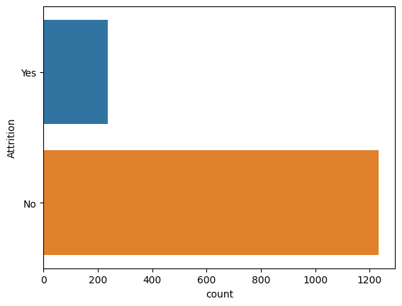

```python
sns.countplot(y="Attrition",data=data)
plt.show()
```

Exploratory Data analysis

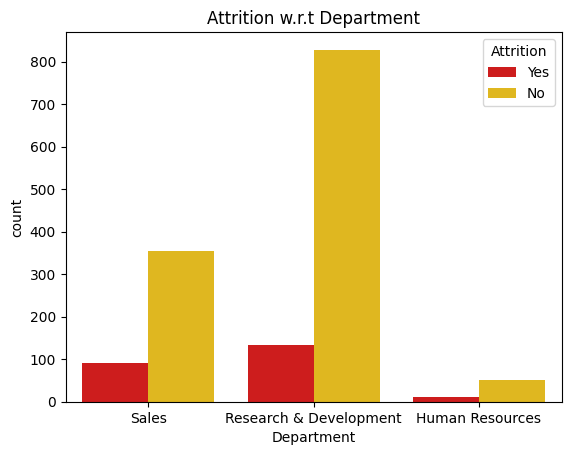

```python
sns.countplot(x='Department',hue='Attrition',data=data,palette='hot')
plt.title("Attrition w.r.t Department")
plt.show()
```

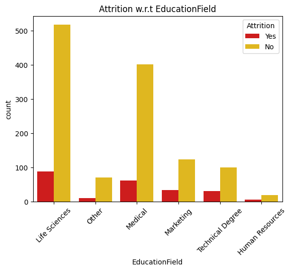

```python
sns.countplot(x='EducationField',hue='Attrition', data=data, palette='hot')
plt.title("Attrition w.r.t EducationField")
plt.xticks(rotation=45)
plt.show()
```

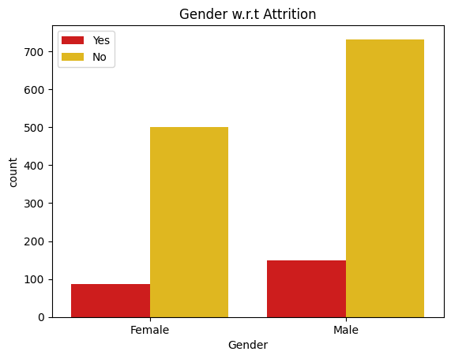

```python
sns.countplot(x='Gender',hue='Attrition', data=data, palette='hot')
plt.title("Gender w.r.t Attrition")
plt.legend(loc='best')
plt.show()
```

Observation:

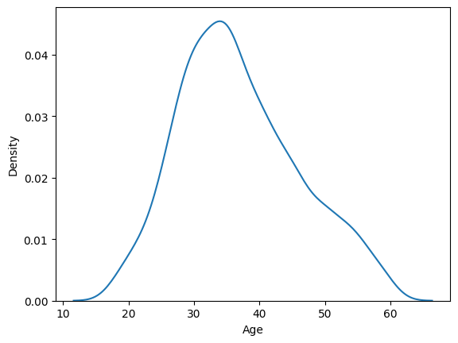

```python
# distribution of age
sns.distplot(data['Age'],hist=False)
plt.show()
```

Age column is very well normalized, most of employees are age between 25 to 40.

we are having some of the numerical columns which are lebel encoded for us, they are ordinal labels, so let's have a look at them first

```python
numerical_col=['Education','EnvironmentSatisfaction','JobInvolvement','JobSatisfaction','PerformanceRating','RelationshipSatisfaction','WorkLifeBalance']
data[numerical_col].head()
```

|  | Education | EnvironmentSatisfaction | JobInvolvement | JobSatisfaction | PerformanceRating | RelationshipSatisfaction | WorkLifeBalance |
| --- | --- | --- | --- | --- | --- | --- | --- |
| 0 | 2 | 2 | 3 | 4 | 3 | 1 | 1 |
| 1 | 1 | 3 | 2 | 2 | 4 | 4 | 3 |
| 2 | 2 | 4 | 2 | 3 | 3 | 2 | 3 |
| 3 | 4 | 4 | 3 | 3 | 3 | 3 | 3 |
| 4 | 1 | 1 | 3 | 2 | 3 | 4 | 3 |

```python
data.columns
```

```
Index(['Age', 'Attrition', 'BusinessTravel', 'DailyRate', 'Department',
       'DistanceFromHome', 'Education', 'EducationField', 'EmployeeCount',
       'EmployeeNumber', 'EnvironmentSatisfaction', 'Gender', 'HourlyRate',
       'JobInvolvement', 'JobLevel', 'JobRole', 'JobSatisfaction',
       'MaritalStatus', 'MonthlyIncome', 'MonthlyRate', 'NumCompaniesWorked',
       'Over18', 'OverTime', 'PercentSalaryHike', 'PerformanceRating',
       'RelationshipSatisfaction', 'StandardHours', 'StockOptionLevel',
       'TotalWorkingYears', 'TrainingTimesLastYear', 'WorkLifeBalance',
       'YearsAtCompany', 'YearsInCurrentRole', 'YearsSinceLastPromotion',
       'YearsWithCurrManager'],
      dtype='object')
```

```python
colu=['EmployeeCount','HourlyRate','MaritalStatus','StockOptionLevel', 'TrainingTimesLastYear','StandardHours']
```

```python
data=data.drop(columns=colu)
data
```

|  | Age | Attrition | BusinessTravel | DailyRate | Department | DistanceFromHome | Education | EducationField | EmployeeNumber | EnvironmentSatisfaction | Gender | JobInvolvement | JobLevel | JobRole | JobSatisfaction | MonthlyIncome | MonthlyRate | NumCompaniesWorked | Over18 | OverTime | PercentSalaryHike | PerformanceRating | RelationshipSatisfaction | TotalWorkingYears | WorkLifeBalance | YearsAtCompany | YearsInCurrentRole | YearsSinceLastPromotion | YearsWithCurrManager |
| --- | --- | --- | --- | --- | --- | --- | --- | --- | --- | --- | --- | --- | --- | --- | --- | --- | --- | --- | --- | --- | --- | --- | --- | --- | --- | --- | --- | --- | --- |
| 0 | 41 | Yes | Travel_Rarely | 1102 | Sales | 1 | 2 | Life Sciences | 1 | 2 | Female | 3 | 2 | Sales Executive | 4 | 5993 | 19479 | 8 | Y | Yes | 11 | 3 | 1 | 8 | 1 | 6 | 4 | 0 | 5 |
| 1 | 49 | No | Travel_Frequently | 279 | Research & Development | 8 | 1 | Life Sciences | 2 | 3 | Male | 2 | 2 | Research Scientist | 2 | 5130 | 24907 | 1 | Y | No | 23 | 4 | 4 | 10 | 3 | 10 | 7 | 1 | 7 |
| 2 | 37 | Yes | Travel_Rarely | 1373 | Research & Development | 2 | 2 | Other | 4 | 4 | Male | 2 | 1 | Laboratory Technician | 3 | 2090 | 2396 | 6 | Y | Yes | 15 | 3 | 2 | 7 | 3 | 0 | 0 | 0 | 0 |
| 3 | 33 | No | Travel_Frequently | 1392 | Research & Development | 3 | 4 | Life Sciences | 5 | 4 | Female | 3 | 1 | Research Scientist | 3 | 2909 | 23159 | 1 | Y | Yes | 11 | 3 | 3 | 8 | 3 | 8 | 7 | 3 | 0 |
| 4 | 27 | No | Travel_Rarely | 591 | Research & Development | 2 | 1 | Medical | 7 | 1 | Male | 3 | 1 | Laboratory Technician | 2 | 3468 | 16632 | 9 | Y | No | 12 | 3 | 4 | 6 | 3 | 2 | 2 | 2 | 2 |
| ... | ... | ... | ... | ... | ... | ... | ... | ... | ... | ... | ... | ... | ... | ... | ... | ... | ... | ... | ... | ... | ... | ... | ... | ... | ... | ... | ... | ... | ... |
| 1465 | 36 | No | Travel_Frequently | 884 | Research & Development | 23 | 2 | Medical | 2061 | 3 | Male | 4 | 2 | Laboratory Technician | 4 | 2571 | 12290 | 4 | Y | No | 17 | 3 | 3 | 17 | 3 | 5 | 2 | 0 | 3 |
| 1466 | 39 | No | Travel_Rarely | 613 | Research & Development | 6 | 1 | Medical | 2062 | 4 | Male | 2 | 3 | Healthcare Representative | 1 | 9991 | 21457 | 4 | Y | No | 15 | 3 | 1 | 9 | 3 | 7 | 7 | 1 | 7 |
| 1467 | 27 | No | Travel_Rarely | 155 | Research & Development | 4 | 3 | Life Sciences | 2064 | 2 | Male | 4 | 2 | Manufacturing Director | 2 | 6142 | 5174 | 1 | Y | Yes | 20 | 4 | 2 | 6 | 3 | 6 | 2 | 0 | 3 |
| 1468 | 49 | No | Travel_Frequently | 1023 | Sales | 2 | 3 | Medical | 2065 | 4 | Male | 2 | 2 | Sales Executive | 2 | 5390 | 13243 | 2 | Y | No | 14 | 3 | 4 | 17 | 2 | 9 | 6 | 0 | 8 |
| 1469 | 34 | No | Travel_Rarely | 628 | Research & Development | 8 | 3 | Medical | 2068 | 2 | Male | 4 | 2 | Laboratory Technician | 3 | 4404 | 10228 | 2 | Y | No | 12 | 3 | 1 | 6 | 4 | 4 | 3 | 1 | 2 |

1470 rows × 29 columns

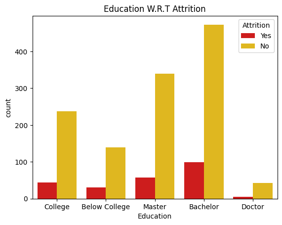

```python
edu_map = {1 :'Below College', 2: 'College', 3 :'Bachelor', 4 :'Master', 5: 'Doctor'}
sns.countplot(x=data['Education'].map(edu_map), hue='Attrition', data=data, palette='hot')
plt.title("Education W.R.T Attrition")
plt.show()
```

OBSERVATIONS Employees from Bachelor are more, then from Masters background. Attrition wrt to bachelor can be seem more because they have more and more expectation from companies and it will be interesting t o see the reason behind this in this dataset.

# Label Encoding

```python
# Target Variable(Attrition)
data['Attrition'] = data['Attrition'].replace({'No':0,'Yes':1})

#encode binary variables
data['OverTime'] = data['OverTime'].map({'No':0,'Yes':1})
data['Gender'] = data['Gender'].map({'Male':0,'Female':1})
```

```python
data.columns
```

```
Index(['Age', 'Attrition', 'BusinessTravel', 'DailyRate', 'Department',
       'DistanceFromHome', 'Education', 'EducationField', 'EmployeeNumber',
       'EnvironmentSatisfaction', 'Gender', 'JobInvolvement', 'JobLevel',
       'JobRole', 'JobSatisfaction', 'MonthlyIncome', 'MonthlyRate',
       'NumCompaniesWorked', 'Over18', 'OverTime', 'PercentSalaryHike',
       'PerformanceRating', 'RelationshipSatisfaction', 'TotalWorkingYears',
       'WorkLifeBalance', 'YearsAtCompany', 'YearsInCurrentRole',
       'YearsSinceLastPromotion', 'YearsWithCurrManager'],
      dtype='object')
```

```python
# encode categorical columns which are ordinal, use labelEncoding
# apply Label encoder to df_categorical
from sklearn.preprocessing import LabelEncoder
encoding_cols=['BusinessTravel','Department','EducationField','JobRole']
label_encoders = {}
for column in encoding_cols:
    label_encoders[column] = LabelEncoder()
    data[column] = label_encoders[column].fit_transform(data[column])
```

```python
data.head()
```

|  | Age | Attrition | BusinessTravel | DailyRate | Department | DistanceFromHome | Education | EducationField | EmployeeNumber | EnvironmentSatisfaction | Gender | JobInvolvement | JobLevel | JobRole | JobSatisfaction | MonthlyIncome | MonthlyRate | NumCompaniesWorked | Over18 | OverTime | PercentSalaryHike | PerformanceRating | RelationshipSatisfaction | TotalWorkingYears | WorkLifeBalance | YearsAtCompany | YearsInCurrentRole | YearsSinceLastPromotion | YearsWithCurrManager |
| --- | --- | --- | --- | --- | --- | --- | --- | --- | --- | --- | --- | --- | --- | --- | --- | --- | --- | --- | --- | --- | --- | --- | --- | --- | --- | --- | --- | --- | --- |
| 0 | 41 | 1 | 2 | 1102 | 2 | 1 | 2 | 1 | 1 | 2 | 1 | 3 | 2 | 7 | 4 | 5993 | 19479 | 8 | Y | 1 | 11 | 3 | 1 | 8 | 1 | 6 | 4 | 0 | 5 |
| 1 | 49 | 0 | 1 | 279 | 1 | 8 | 1 | 1 | 2 | 3 | 0 | 2 | 2 | 6 | 2 | 5130 | 24907 | 1 | Y | 0 | 23 | 4 | 4 | 10 | 3 | 10 | 7 | 1 | 7 |
| 2 | 37 | 1 | 2 | 1373 | 1 | 2 | 2 | 4 | 4 | 4 | 0 | 2 | 1 | 2 | 3 | 2090 | 2396 | 6 | Y | 1 | 15 | 3 | 2 | 7 | 3 | 0 | 0 | 0 | 0 |
| 3 | 33 | 0 | 1 | 1392 | 1 | 3 | 4 | 1 | 5 | 4 | 1 | 3 | 1 | 6 | 3 | 2909 | 23159 | 1 | Y | 1 | 11 | 3 | 3 | 8 | 3 | 8 | 7 | 3 | 0 |
| 4 | 27 | 0 | 2 | 591 | 1 | 2 | 1 | 3 | 7 | 1 | 0 | 3 | 1 | 2 | 2 | 3468 | 16632 | 9 | Y | 0 | 12 | 3 | 4 | 6 | 3 | 2 | 2 | 2 | 2 |

# Machine Learning

```python
x = data.drop(['Attrition','Over18'], axis=1)
y = data['Attrition'].values
```

```python
x
```

|  | Age | BusinessTravel | DailyRate | Department | DistanceFromHome | Education | EducationField | EmployeeNumber | EnvironmentSatisfaction | Gender | JobInvolvement | JobLevel | JobRole | JobSatisfaction | MonthlyIncome | MonthlyRate | NumCompaniesWorked | OverTime | PercentSalaryHike | PerformanceRating | RelationshipSatisfaction | TotalWorkingYears | WorkLifeBalance | YearsAtCompany | YearsInCurrentRole | YearsSinceLastPromotion | YearsWithCurrManager |
| --- | --- | --- | --- | --- | --- | --- | --- | --- | --- | --- | --- | --- | --- | --- | --- | --- | --- | --- | --- | --- | --- | --- | --- | --- | --- | --- | --- |
| 0 | 41 | 2 | 1102 | 2 | 1 | 2 | 1 | 1 | 2 | 1 | 3 | 2 | 7 | 4 | 5993 | 19479 | 8 | 1 | 11 | 3 | 1 | 8 | 1 | 6 | 4 | 0 | 5 |
| 1 | 49 | 1 | 279 | 1 | 8 | 1 | 1 | 2 | 3 | 0 | 2 | 2 | 6 | 2 | 5130 | 24907 | 1 | 0 | 23 | 4 | 4 | 10 | 3 | 10 | 7 | 1 | 7 |
| 2 | 37 | 2 | 1373 | 1 | 2 | 2 | 4 | 4 | 4 | 0 | 2 | 1 | 2 | 3 | 2090 | 2396 | 6 | 1 | 15 | 3 | 2 | 7 | 3 | 0 | 0 | 0 | 0 |
| 3 | 33 | 1 | 1392 | 1 | 3 | 4 | 1 | 5 | 4 | 1 | 3 | 1 | 6 | 3 | 2909 | 23159 | 1 | 1 | 11 | 3 | 3 | 8 | 3 | 8 | 7 | 3 | 0 |
| 4 | 27 | 2 | 591 | 1 | 2 | 1 | 3 | 7 | 1 | 0 | 3 | 1 | 2 | 2 | 3468 | 16632 | 9 | 0 | 12 | 3 | 4 | 6 | 3 | 2 | 2 | 2 | 2 |
| ... | ... | ... | ... | ... | ... | ... | ... | ... | ... | ... | ... | ... | ... | ... | ... | ... | ... | ... | ... | ... | ... | ... | ... | ... | ... | ... | ... |
| 1465 | 36 | 1 | 884 | 1 | 23 | 2 | 3 | 2061 | 3 | 0 | 4 | 2 | 2 | 4 | 2571 | 12290 | 4 | 0 | 17 | 3 | 3 | 17 | 3 | 5 | 2 | 0 | 3 |
| 1466 | 39 | 2 | 613 | 1 | 6 | 1 | 3 | 2062 | 4 | 0 | 2 | 3 | 0 | 1 | 9991 | 21457 | 4 | 0 | 15 | 3 | 1 | 9 | 3 | 7 | 7 | 1 | 7 |
| 1467 | 27 | 2 | 155 | 1 | 4 | 3 | 1 | 2064 | 2 | 0 | 4 | 2 | 4 | 2 | 6142 | 5174 | 1 | 1 | 20 | 4 | 2 | 6 | 3 | 6 | 2 | 0 | 3 |
| 1468 | 49 | 1 | 1023 | 2 | 2 | 3 | 3 | 2065 | 4 | 0 | 2 | 2 | 7 | 2 | 5390 | 13243 | 2 | 0 | 14 | 3 | 4 | 17 | 2 | 9 | 6 | 0 | 8 |
| 1469 | 34 | 2 | 628 | 1 | 8 | 3 | 3 | 2068 | 2 | 0 | 4 | 2 | 2 | 3 | 4404 | 10228 | 2 | 0 | 12 | 3 | 1 | 6 | 4 | 4 | 3 | 1 | 2 |

1470 rows × 27 columns

```python
y
```

```
array([1, 0, 1, ..., 0, 0, 0], dtype=int64)
```

```python
from sklearn.model_selection import train_test_split
x_train, x_test, y_train, y_test = train_test_split(x, y, test_size=0.2, random_state=56)
```

```python
print(x_train.shape)
print(y_train.shape)
print(x_test.shape)
print(y_test.shape)
```

```
(1176, 27)
(1176,)
(294, 27)
(294,)
```

```python
from sklearn.linear_model import LogisticRegression
from sklearn.metrics import confusion_matrix, accuracy_score
```

```python
logreg = LogisticRegression()
logreg.fit(x_train, y_train)
```

```
LogisticRegression()
```

```python
prediction=logreg.predict(x_test)
cm = confusion_matrix(y_test,prediction)
```

```python
cm
```

```
array([[246,   0],
       [ 48,   0]], dtype=int64)
```

```python
ac=accuracy_score(y_test , prediction)
```

```python
ac
```

```
0.8367346938775511
```

Decision Tree

```python
from sklearn.tree import DecisionTreeClassifier
```

```python
x_train, x_test, y_train, y_test = train_test_split(x, y, test_size=0.2, random_state=40)
```

```python
cls = DecisionTreeClassifier()
```

```python
cls.fit(x_train,y_train)
```

```
DecisionTreeClassifier()
```

```python
pred=cls.predict(x_test)
```

```python
pred
```

```
array([0, 1, 0, 0, 0, 0, 1, 0, 0, 0, 0, 0, 0, 0, 0, 0, 0, 1, 0, 1, 0, 0,
       0, 0, 1, 0, 0, 0, 0, 0, 0, 0, 0, 0, 0, 0, 1, 0, 0, 1, 1, 0, 0, 1,
       1, 0, 0, 0, 1, 0, 0, 0, 0, 1, 0, 0, 0, 0, 0, 0, 0, 0, 0, 0, 0, 0,
       0, 0, 0, 0, 0, 0, 0, 0, 1, 0, 0, 1, 0, 0, 0, 0, 1, 1, 0, 0, 1, 0,
       0, 0, 0, 0, 1, 0, 0, 0, 0, 0, 0, 0, 0, 0, 0, 0, 0, 0, 0, 0, 0, 0,
       1, 0, 1, 0, 0, 0, 0, 0, 1, 0, 0, 0, 0, 0, 0, 0, 0, 1, 1, 0, 1, 0,
       0, 0, 0, 0, 0, 0, 0, 0, 0, 0, 0, 0, 0, 0, 0, 0, 0, 0, 0, 0, 0, 1,
       0, 0, 0, 0, 0, 0, 1, 0, 0, 0, 1, 0, 0, 1, 0, 0, 0, 0, 1, 1, 0, 1,
       0, 0, 0, 0, 0, 0, 0, 1, 0, 0, 0, 0, 0, 0, 0, 0, 0, 0, 0, 0, 0, 0,
       0, 0, 0, 0, 0, 0, 0, 0, 0, 0, 0, 0, 0, 1, 0, 0, 0, 1, 0, 0, 0, 0,
       0, 0, 0, 1, 0, 1, 0, 0, 1, 1, 0, 0, 0, 0, 0, 0, 0, 0, 0, 1, 0, 0,
       0, 0, 0, 0, 0, 0, 0, 1, 0, 1, 0, 0, 0, 0, 0, 0, 0, 0, 0, 0, 0, 0,
       0, 0, 1, 0, 1, 0, 0, 0, 1, 0, 0, 1, 0, 0, 0, 0, 0, 0, 0, 0, 0, 0,
       0, 0, 0, 0, 0, 0, 1, 0], dtype=int64)
```

```python
cm = confusion_matrix(y_test,pred)
cm
```

```
array([[213,  32],
       [ 35,  14]], dtype=int64)
```

```python
ac=accuracy_score(y_test , pred)
ac
```

```
0.7721088435374149
```

# RandomForest Classifier

Random Forest is a popular machine learning algorithm used for both classification and regression tasks. It is an ensemble learning method that combines the predictions of multiple decision trees to improve overall predictive accuracy and reduce overfitting. Random Forest introduces randomness by selecting a random subset of features (variables or attributes) for each tree. This helps to decorrelate the trees and improve the overall performance of the ensemble. To make predictions, Random Forest combines the outputs of individual decision trees. For classification tasks, it typically uses a majority vote among the trees to determine the depedent variable or target variable

```python
from sklearn.ensemble import RandomForestClassifier
```

```python
x_train,x_test,y_train,y_test=train_test_split(x,y,test_size=0.3,random_state=123)
```

```python
rnd=RandomForestClassifier(n_estimators=50)
#n_estimators means decide the number of decision tree

rnd.fit(x_train,y_train)
```

```
RandomForestClassifier(n_estimators=50)
```

```python
rnd_prd=rnd.predict(x_test)
```

```python
cm = confusion_matrix(y_test,rnd_prd)
cm
```

```
array([[382,   2],
       [ 44,  13]], dtype=int64)
```

```python
ac=accuracy_score(y_test,rnd_prd)
ac
```

```
0.8956916099773242
```

# Naive Bayes Algorithm

Naive Bayes is a simple and probabilistic machine learning algorithm used for classification The "naive" in Naive Bayes comes from the assumption that all features used in the model are independent of each other. This is a simplifying assumption, as in many real-world scenarios, features may be correlated. Despite this simplification, Naive Bayes often performs surprisingly well in practice and can provide decent results, especially when the independence assumption is reasonably close to reality

```python
from sklearn.preprocessing import StandardScaler
from sklearn.naive_bayes import GaussianNB
```

```python
x_train,x_test,y_train,y_test=train_test_split(x,y,test_size=0.3,random_state=50)
```

```python
scaler=StandardScaler()
x_train=scaler.fit_transform(x_train)
x_test=scaler.fit_transform(x_test)
```

```python
model=GaussianNB()
```

```python
model.fit(x_train,y_train)
```

```
GaussianNB()
```

```python
Gau_prd=model.predict(x_test)
```

```python
Gau_prd
```

```
array([1, 0, 0, 0, 0, 0, 1, 0, 1, 0, 1, 0, 1, 1, 0, 1, 0, 1, 1, 0, 0, 0,
       1, 0, 0, 0, 0, 0, 0, 0, 0, 0, 0, 1, 0, 0, 0, 0, 0, 0, 1, 0, 0, 0,
       0, 0, 0, 0, 0, 0, 1, 0, 0, 0, 0, 0, 1, 0, 0, 0, 0, 0, 0, 0, 0, 1,
       1, 0, 0, 0, 0, 1, 1, 1, 0, 0, 0, 0, 0, 0, 0, 0, 0, 0, 0, 1, 0, 0,
       1, 1, 0, 1, 0, 0, 0, 1, 0, 1, 0, 0, 0, 1, 0, 0, 1, 1, 0, 1, 0, 0,
       0, 0, 0, 0, 0, 0, 0, 0, 0, 0, 1, 0, 0, 0, 1, 0, 0, 0, 0, 0, 0, 0,
       0, 1, 1, 0, 0, 0, 0, 1, 1, 1, 0, 0, 0, 1, 0, 1, 1, 0, 1, 0, 0, 0,
       1, 1, 0, 0, 0, 0, 0, 0, 0, 0, 1, 0, 1, 1, 1, 1, 0, 1, 0, 0, 0, 0,
       1, 0, 0, 1, 0, 0, 0, 0, 1, 0, 0, 0, 0, 0, 1, 0, 1, 1, 0, 0, 0, 1,
       1, 0, 1, 0, 0, 0, 0, 0, 0, 0, 0, 0, 0, 1, 1, 1, 0, 0, 1, 1, 0, 1,
       0, 0, 0, 0, 1, 1, 1, 0, 0, 0, 0, 0, 0, 0, 0, 0, 1, 0, 0, 1, 0, 1,
       0, 1, 0, 0, 0, 0, 0, 1, 1, 0, 0, 0, 0, 0, 1, 0, 0, 0, 0, 0, 0, 0,
       0, 0, 0, 1, 0, 1, 0, 0, 0, 0, 0, 0, 1, 0, 1, 1, 0, 1, 0, 0, 1, 0,
       0, 0, 0, 0, 1, 1, 1, 1, 1, 1, 0, 0, 1, 1, 0, 1, 1, 0, 0, 0, 0, 0,
       0, 0, 0, 0, 0, 0, 0, 0, 0, 0, 0, 0, 1, 0, 0, 0, 0, 0, 0, 0, 0, 1,
       0, 0, 0, 0, 0, 0, 0, 1, 0, 1, 0, 1, 1, 0, 1, 0, 0, 0, 0, 0, 1, 0,
       0, 0, 1, 0, 0, 0, 0, 1, 0, 1, 0, 0, 0, 0, 0, 0, 0, 0, 0, 0, 0, 1,
       0, 0, 1, 1, 1, 1, 0, 0, 0, 0, 0, 1, 0, 0, 0, 1, 0, 1, 1, 0, 0, 0,
       0, 0, 0, 0, 0, 0, 1, 0, 0, 1, 0, 1, 0, 0, 0, 0, 1, 0, 0, 0, 1, 1,
       0, 0, 0, 1, 0, 1, 0, 0, 0, 0, 0, 1, 0, 0, 0, 0, 0, 0, 0, 0, 1, 0,
       0], dtype=int64)
```

```python
cm = confusion_matrix(y_test,Gau_prd)
cm
```

```
array([[299,  71],
       [ 22,  49]], dtype=int64)
```

```python
ac=accuracy_score(y_test,Gau_prd)
ac
```

```
0.7891156462585034
```

# k-Nearest neighbours

```python
from sklearn.model_selection import train_test_split,cross_val_score
from sklearn.neighbors import KNeighborsClassifier
```

```python
xtrain,xtest,ytrain,ytest=train_test_split(x,y,test_size=0.3,random_state=30)
```

```python
#find best k
b_k=None
b_a=0
#iteration of accuracy
for k in range(1,10):
    knn=KNeighborsClassifier(n_neighbors=k)
    scores=cross_val_score(knn,xtrain,ytrain,cv=5)
    print(scores)
    m_a=np.mean(scores)
    print(m_a)
    if m_a>b_a:
        b_a=m_a
        b_k=k
```

```
[0.74757282 0.73300971 0.68932039 0.76213592 0.71219512]
0.7288467913805352
[0.7961165  0.83495146 0.82524272 0.82524272 0.81463415]
0.8192375088799432
[0.74757282 0.7961165  0.80582524 0.80582524 0.8       ]
0.7910679611650485
[0.80582524 0.83495146 0.83495146 0.83980583 0.82926829]
0.8289604546530901
[0.78640777 0.83495146 0.82524272 0.83495146 0.82439024]
0.8211887283921383
[0.83495146 0.83495146 0.83495146 0.83980583 0.83414634]
0.8357613071276344
[0.81553398 0.83980583 0.82524272 0.84951456 0.83902439]
0.8338242955245085
[0.83980583 0.83980583 0.83009709 0.83980583 0.83902439]
0.8377077906701397
[0.83009709 0.83980583 0.82524272 0.83495146 0.83902439]
0.8338242955245085
```

```python
b_k
```

```
8
```

```python
knn=KNeighborsClassifier(n_neighbors=b_k)
```

```python
knn.fit(xtrain,ytrain)
```

```
KNeighborsClassifier(n_neighbors=8)
```

```python
knn_predict=knn.predict(xtest)
```

```python
knn_predict
```

```
array([0, 0, 0, 0, 0, 0, 0, 0, 0, 0, 0, 0, 0, 0, 0, 0, 0, 0, 0, 0, 0, 0,
       0, 0, 0, 0, 0, 0, 0, 0, 0, 0, 0, 1, 0, 0, 0, 0, 0, 0, 0, 0, 0, 0,
       0, 0, 0, 0, 0, 0, 0, 0, 0, 0, 0, 1, 0, 1, 0, 0, 0, 0, 0, 0, 0, 0,
       0, 0, 0, 0, 0, 0, 0, 0, 0, 0, 0, 0, 0, 0, 0, 0, 0, 0, 0, 0, 0, 0,
       0, 0, 0, 0, 0, 0, 0, 0, 0, 0, 0, 0, 0, 0, 0, 0, 0, 0, 0, 0, 0, 0,
       0, 0, 0, 0, 0, 0, 0, 0, 0, 0, 0, 0, 0, 0, 0, 0, 0, 0, 0, 0, 0, 0,
       0, 0, 0, 0, 0, 0, 0, 0, 0, 0, 0, 0, 0, 0, 0, 0, 0, 0, 0, 0, 0, 0,
       0, 0, 0, 0, 0, 0, 0, 0, 0, 0, 0, 0, 0, 0, 0, 0, 0, 0, 0, 0, 0, 0,
       0, 0, 0, 0, 0, 0, 0, 0, 0, 0, 1, 0, 0, 0, 0, 0, 0, 0, 0, 0, 0, 0,
       0, 0, 0, 0, 0, 1, 0, 0, 0, 0, 0, 0, 0, 1, 0, 0, 0, 0, 0, 0, 0, 0,
       0, 0, 0, 0, 0, 0, 0, 0, 0, 0, 0, 0, 0, 0, 0, 0, 0, 0, 0, 0, 0, 0,
       0, 0, 0, 0, 0, 0, 0, 0, 0, 0, 0, 0, 0, 0, 0, 0, 0, 0, 0, 0, 0, 0,
       0, 0, 0, 0, 0, 0, 0, 0, 0, 0, 1, 0, 0, 0, 0, 0, 0, 0, 0, 0, 0, 0,
       0, 0, 0, 0, 1, 0, 0, 0, 0, 0, 0, 0, 0, 0, 0, 0, 0, 0, 0, 0, 0, 0,
       0, 0, 0, 0, 0, 0, 0, 0, 0, 0, 0, 0, 0, 0, 0, 0, 0, 0, 0, 0, 0, 0,
       0, 0, 0, 0, 0, 0, 0, 0, 0, 0, 0, 0, 0, 0, 0, 0, 0, 0, 0, 0, 0, 0,
       0, 0, 0, 0, 0, 0, 0, 0, 0, 0, 0, 0, 0, 0, 0, 0, 0, 0, 0, 0, 0, 0,
       0, 0, 0, 0, 0, 0, 0, 0, 0, 0, 0, 0, 0, 0, 0, 0, 0, 0, 0, 0, 0, 0,
       0, 0, 0, 0, 0, 0, 0, 0, 0, 0, 0, 0, 0, 0, 0, 0, 0, 0, 0, 0, 0, 0,
       0, 0, 0, 0, 0, 0, 0, 0, 0, 0, 0, 0, 0, 0, 0, 0, 0, 0, 0, 0, 0, 0,
       0], dtype=int64)
```

```python
cm = confusion_matrix(ytest,knn_predict)
cm
```

```
array([[368,   4],
       [ 65,   4]], dtype=int64)
```

```python
ac=accuracy_score(y_test,knn_predict)
ac
```

```
0.8208616780045351
```

# ANN(backward probagation)

```python
from sklearn.preprocessing import StandardScaler
from sklearn.neural_network import MLPClassifier
```

```python
x_train,x_test,y_train,y_test=train_test_split(x,y,test_size=0.3,random_state=50)
```

```python
sc=StandardScaler()
x_train=sc.fit_transform(x_train)
x_test=sc.fit_transform(x_test)
```

```python
nm=MLPClassifier(hidden_layer_sizes=(10,),max_iter=1100,random_state=59)
```

```python
nm.fit(x_train,y_train)
```

```
MLPClassifier(hidden_layer_sizes=(10,), max_iter=1100, random_state=59)
```

```python
nm.score(x_test,y_test)
```

```
0.8480725623582767
```

```python
train_ac=[]
check_ac=[]
```

```python
for epoch in range(1,101):
    nm.fit(x_train,y_train)
    train_ac.append(nm.score(x_train,y_train))
    check_ac.append(nm.score(x_test,y_test))
```

```python
acc=nm.score(x_test,y_test)
acc
```

[output not shown]

```python
plt.plot(range(1,101),train_ac,label="train_accuracy")
plt.plot(range(1,101),check_ac,label="val accuracy")
plt.xlabel('Epoch')
plt.ylabel('Accuracy')
plt.legend()
plt.grid(True)
```

[output not shown]